# Home range de alimentación del pingüino Papua (Pygoscelis papua)

Nicolás Fernández Sauleda

2023-05-22

# Aclaración

Este trabajo se encuentra escrito en *R markdown* y la información va a ser detallada a lo largo del análisis.

## Introducción y objetivo

El presente trabajo busca identificar el home range de alimentación de una colonia de pingüinos Papua (*Pygoscelis papua*) en la Isla Ardley, ubicada en la Antártida durante un mes, desde diciembre del 2022 a enero del 2023.

Esta área es de debida importancia, ya que ha sido identificada como un área importante para la conservación de las aves por BirdLife International, 2017.

Se colocaron veintiún dispositivos GPS a pingüinos Papua (Pygoscelis papua) de la colonia ubicada en la isla Ardley, que se encuentra en la bahía Maxwell, cerca del extremo suroeste de la isla Rey Jorge, en las islas Shetland del Sur de la Antártida. Los dispositivos grabaron localizaciones desde 2022-12-03 hasta 2023-01-03, con un total de 329.517 registros. Once dispositivos tomaron datos cada 60 segundos, los diez restantes lo hicieron cada 10 segundos. En el presente trabajo solo utilizaremos aquellos que registraron cada 60 segundos.

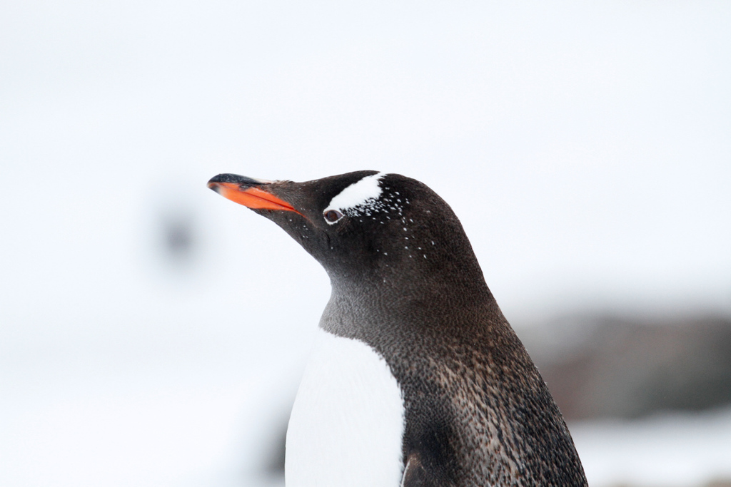

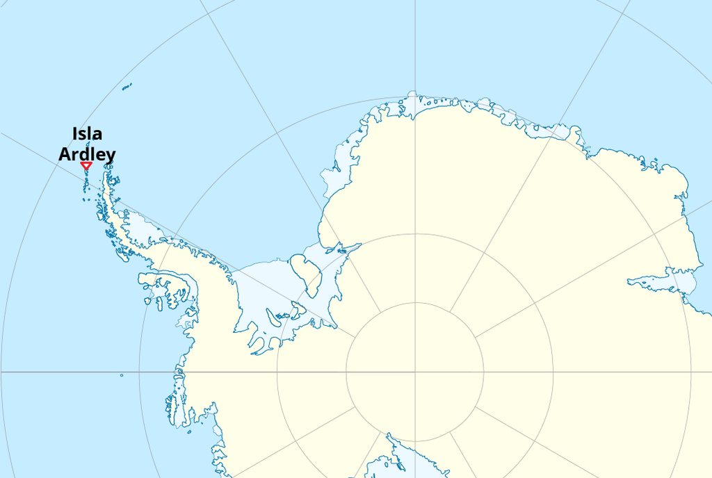

BirdLife International (2023) Important Bird Area factsheet: Ardley Island, King George Island. Downloaded from http://datazone.birdlife.org/site/factsheet/29408 on 22/05/2023.

## Procesado y primera aproximación.

```r
library(tidyverse)
library(rmarkdown)
library(sf)
library(rnaturalearth)
library(move)
library(argosfilter)
library(sf)
library(sp)
library(amt)
library(adehabitatHR)
library(adehabitatMA)
library(adehabitatLT)
library(track2KBA)
library(tmap)
```

### Carga de datos

Empezamos por cargar los datos desde los `.txt`.

```r
my_path <- "C:/Users/wjuic/Desktop/Muchacosa/Facultad/EcologiaDelMovimiento/Ecologia-del-movimiento/entrega_final/"

files <- list.files(path = "raw_data/", full.names = TRUE, pattern = ".txt") %>%
  str_sub(10,-1)

gps_ids <- files %>%
  str_sub(1,-13)

gps_all <- data.frame()

for (i in 1:length(files)) {
  gps_data_i <-
    read.table(paste0(my_path, "/raw_data/", files[i]),
           stringsAsFactors = FALSE,
           fill = TRUE) %>%
    dplyr::select(1:4) %>%
    dplyr::mutate(gps_id = gps_ids[i])

  gps_all <- bind_rows(gps_all,
                       gps_data_i)
  #print(paste0("File ", gps_ids[i], " loaded."))
}

rm(gps_data_i, i, gps_ids, files)
```

Una vez cargados todos los archivos, le asigno un nombre a cada columna y las ordeno.

```r
gps_all <- gps_all %>%
  dplyr::rename("date" = V1,
         "time" = V2,
         "lat" = V3,
         "long" = V4) %>%
  dplyr::select(gps_id, date, time, lat, long)
```

Convierto las columnas de date y time a una sola en formato timestamp y en GMT.

```r
gps_all <- gps_all %>%
  mutate(datetime = as.POSIXct(dmy_hms(paste0(date, " ", time), tz="GMT"))) %>%
  dplyr::select(gps_id, datetime, lat, long, -date, -time)
```

Visualizamos:

|  | gps_id | datetime | lat | long |
| --- | --- | --- | --- | --- |
| 1 | ARDP001 | 2022-12-03 14:35:02 | -62.21188 | -58.91903 |
| 2 | ARDP001 | 2022-12-03 14:35:11 | -62.21190 | -58.91908 |
| 3 | ARDP001 | 2022-12-03 14:35:21 | -62.21191 | -58.91892 |
| 4 | ARDP001 | 2022-12-03 14:35:31 | -62.21190 | -58.91905 |
| 5 | ARDP001 | 2022-12-03 14:35:40 | -62.21187 | -58.91907 |
| 6 | ARDP001 | 2022-12-03 14:35:50 | -62.21191 | -58.91921 |

## Filtrado de datos tierra/agua

Por limitaciones en mi computadora no puedo correr el algoritmo que identifica puntos en tierra y agua para todos los individuos. Igualmente, voy a demostrar como se haría para un individuo:

### Para un individuo

Selecciono los registros para el individuo “ARDP022”.

```r
one_ind <- gps_all %>%
  dplyr::filter(gps_id == "ARDP022")

one_ind_sf_polar <- st_as_sf(x = one_ind, coords = c("long", "lat"), crs = "EPSG:4326") %>%
  st_transform(crs="EPSG:3031")
```

Cargo shapefile del coastline de Antártida (versión recortada, más liviana).

```r
coastline_polar_rip <- sf::read_sf("./data/antartica_study_area/antartica_study_area.shp", crs = "EPSG:3031")
```

La función `st_join` con el argumento `st_within` clasifica los puntos que caen completamente dentro del polígono que contiene al continente

```r
one_ind_sf_polar_points_filtered <- st_join(one_ind_sf_polar,
                            coastline_polar_rip,
                            join = st_within)
```

Visualizo la cantidad de puntos que caen en agua y en tierra:

```r
one_ind_sf_polar_points_filtered %>%
  as_tibble() %>%
  group_by(SURFACE) %>%
  summarise(n=n()) %>%
  paged_table()
```

| SURFACE | n |
| --- | --- |
| land | 17731 |
| NA | 870 |

Grafico:

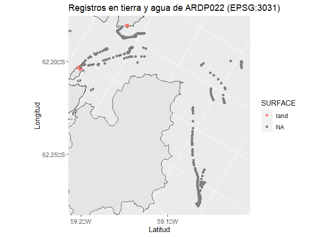

```r
ggplot()+
  geom_sf(data = coastline_polar_rip) +
  geom_sf(data = one_ind_sf_polar_points_filtered, aes(colour = SURFACE)) +
  coord_sf(xlim = c(st_bbox(one_ind_sf_polar_points_filtered)[[1]], st_bbox(one_ind_sf_polar_points_filtered)[[3]]),
           ylim = c(st_bbox(one_ind_sf_polar_points_filtered)[[2]], st_bbox(one_ind_sf_polar_points_filtered)[[4]])) +
  ggtitle("Registros en tierra y agua de ARDP022 (EPSG:3031)") +
  xlab("Latitud") + ylab("Longitud")
```

### Para todos los individuos

Como no puedo procesarlos mediante R, por cuestiones técnicas, paso los datos a QGIS. Primero paso los registros a un formato `.shp` para poder cargarlos en QGIS.

```r
st_as_sf(x = gps_all, coords = c("long", "lat"), crs = "EPSG:4326") %>%
  st_transform( crs="EPSG:3031") %>%
  st_write("data/qgis/exportados_R/my_shapefile.shp")
```

En QGIS añado una columna boolean llamada “on_land”, los datos que están en continente se les agrega un `TRUE` y `FALSE` para los que están fuera. Los cargo de nuevo a R y continúo con el análisis. Se omite un procesado a la tabla que se extrae de QGIS para no saturar de información, se mantiene en el código del presente archivo.

```r
load(file = "data/rdata/filtered_post_qgis.RData") # Cargo los datos
```

Antes de visualizar voy a filtrar los datos para quedarme con los GPS que registraron cada 60 segundos.

```r
gps_60sec <- gps_sf_polar %>%
  group_by(gps_id) %>%
  arrange(datetime) %>%
  mutate(lagg = difftime(datetime, lag(datetime), units="secs")) %>%
  drop_na() %>%
  summarise(meanLag=mean(lagg), minLag=min(lagg), maxLag=max(lagg), medianLag=median(lagg))%>%
  dplyr::filter(medianLag == 60) %>%
  pull(gps_id)
```

Los individuos que poseen un registro cada 60 segundos son: ARDP003, ARDP004, ARDP005, ARDP006, ARDP007, ARDP008, ARDP010, ARDP012, ARDP013, ARDP015, ARDP017. Pasemos a filtrarlos.

```r
gps_df <- gps_sf_polar %>%
  st_transform(crs = st_crs("EPSG:4326")) %>%
  mutate(long = st_coordinates(.)[,1], lat = st_coordinates(.)[,2]) %>%
  as_tibble() %>%
  dplyr::select(-geometry, -id) %>%
  dplyr::filter(gps_id %in% gps_60sec) %>%
  as.data.frame()
```

Y visualizamos:

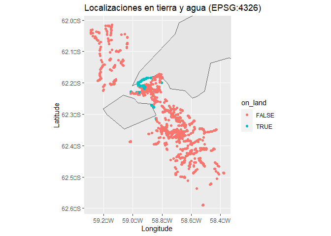

```r
coastline <- ne_countries(scale = "medium", returnclass = "sf")

ggplot() +
  geom_sf(data=coastline) +
  geom_point(data = gps_df, aes(x= gps_df$long, y=gps_df$lat, colour = on_land)) +
  coord_sf(xlim = c(as.numeric(min(gps_df$long)), as.numeric(max(gps_df$long))),
           ylim = c(as.numeric(min(gps_df$lat)), as.numeric(max(gps_df$lat)))) +
   ggtitle("Localizaciones en tierra y agua (EPSG:4326)") +
      xlab("Longitude") + ylab("Latitude")
```

# Identificación de trips

Desarrollé un algoritmo para identificar trips. Se basa en tres elementos:

1. Distancia al punto de origen.
2. Latencia con el registro anterior.
3. Si el punto no se encuentra en el continente.

¿Cómo funciona?

1. Filtra y se queda solo con los puntos en agua y que estén a una distancia mayor a 500 metros al punto inicial.
2. Calcula la latencia entre los puntos filtrados.

Primero creo un objeto move.

```r
data_move <- move(x = gps_df$long,
                  y = gps_df$lat,
                  time = as.POSIXct(gps_df$datetime, format="%Y-%m-%d %H:%M:%S", tz="GMT"),
                  proj = CRS("+proj=longlat +ellps=WGS84"),
                  data = gps_df,
                  animal = gps_df$gps_id,
                  sensor = "gps")

gps_df_filtered <- gps_df %>%
  dplyr::mutate(distance_from_p1 = spDistsN1(coordinates(data_move), coordinates(data_move)[1,], longlat=T)) %>%  # Calcula distancias de los puntos al primer punto.
  mutate(distance_from_p1 = round(distance_from_p1, 2)) %>% # Los redondeo, no tiene sentido menos distancia que 10 metros.
  dplyr::filter(on_land == FALSE) %>%
  as.data.frame() %>%
  group_by(gps_id) %>%
  filter(distance_from_p1 >=0.5) %>%  # Nos quedamos solo con los puntos que esten lejos de la colonia
  mutate(lag_points = round(difftime(datetime, lag(datetime), units="hours"), 0),
         dist_km= c(argosfilter::distanceTrack(lat = lat, lon = long), NA),
         dist_km = round(dist_km, 2)) %>%
  ungroup()

all_data_list <-   gps_df_filtered %>%
  group_by(gps_id) %>%
  group_split()
```

En el bucle:

1. Itinera cada fila.
2. Si la latencia con el punto anterior es de más de 8 horas crea un nuevo trip.
3. Si es menor continua con el trip anterior.

```r
gps_df_filtered <- gps_df[0,] # Dataframe vacío con las mismas columnas.
for (j in 1:length(all_data_list)) {
  trip_count <- 1

  data_trips <- all_data_list[[j]]

  data_trips <- data_trips %>%
    mutate(trips = paste0(gps_60sec[j],"_trip_1"))

  # Arranca en 2 porque "saltea" al punto 1.
  for (n in 2:nrow(data_trips)) {
    # Datos
    n_1 <- n-1

    # Latencia con el punto anterior.
    lag_from_previous <- data_trips$lag_points[n]

    if (lag_from_previous >= 8) { # Latencia de más de 8 horas con el punto anterior.
      # Crea un trip nuevo.
      trip_count <- trip_count + 1
      data_trips <- data_trips %>%
        dplyr::mutate(trips = ifelse(row_number() == n, paste0(gps_60sec[j], "_trip_", trip_count), trips))
    }

    if (lag_from_previous < 8){ # Latencia de menos de 8 horas con el punto anterior.
      # Continua el trip.
      data_trips <- data_trips %>%
        dplyr::mutate( trips = ifelse(row_number() == n, data_trips$trips[n_1], trips))
    }
  }
  # Añado la tabla modificada a las otras.
  gps_df_filtered <- rbind(gps_df_filtered, data_trips)
  #print(paste0(j,"/", length(all_data_list)))
}
```

Visualizamos la tabla:

| gps_id | datetime | on_land | long | lat | distance_from_p1 | lag_points | dist_km | trips |
| --- | --- | --- | --- | --- | --- | --- | --- | --- |
| ARDP003 | 2022-12-05 15:25:58 | FALSE | -58.80738 | -62.34737 | 16.14 | NA hours | 0.00 | ARDP003_trip_1 |
| ARDP003 | 2022-12-05 15:26:02 | FALSE | -58.80739 | -62.34741 | 16.15 | 0 hours | 0.07 | ARDP003_trip_1 |
| ARDP003 | 2022-12-05 15:27:05 | FALSE | -58.80691 | -62.34796 | 16.21 | 0 hours | 0.02 | ARDP003_trip_1 |
| ARDP003 | 2022-12-05 15:28:17 | FALSE | -58.80730 | -62.34784 | 16.19 | 0 hours | 0.05 | ARDP003_trip_1 |
| ARDP003 | 2022-12-05 15:29:20 | FALSE | -58.80716 | -62.34828 | 16.24 | 0 hours | 0.06 | ARDP003_trip_1 |
| ARDP003 | 2022-12-05 15:30:02 | FALSE | -58.80697 | -62.34880 | 16.30 | 0 hours | 0.04 | ARDP003_trip_1 |
| ARDP003 | 2022-12-05 15:31:29 | FALSE | -58.80701 | -62.34918 | 16.34 | 0 hours | 0.02 | ARDP003_trip_1 |
| ARDP003 | 2022-12-05 15:32:02 | FALSE | -58.80687 | -62.34930 | 16.35 | 0 hours | 0.09 | ARDP003_trip_1 |
| ARDP003 | 2022-12-05 15:33:04 | FALSE | -58.80708 | -62.35010 | 16.43 | 0 hours | 0.05 | ARDP003_trip_1 |
| ARDP003 | 2022-12-05 15:34:06 | FALSE | -58.80718 | -62.35058 | 16.48 | 0 hours | 0.04 | ARDP003_trip_1 |

[output cut: 3695 more lines]

Graficamos los trips del individuo ARDP017.

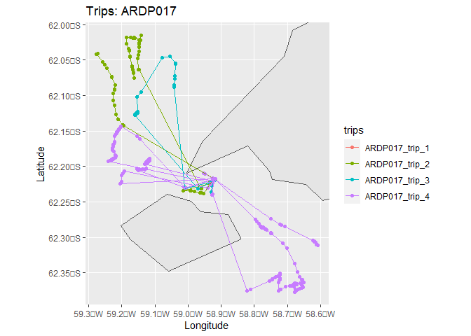

```r
trips_ARDP017 <- gps_df_filtered %>%
  filter(gps_id == "ARDP017")

ggplot() +
  geom_sf(data=coastline) +
  geom_point(data = trips_ARDP017, aes(x= long, y=lat, colour = trips)) +
  geom_path(data = trips_ARDP017, aes(x= long, y=lat, colour = trips)) +
  coord_sf(xlim = c(as.numeric(min(trips_ARDP017$long)), as.numeric(max(trips_ARDP017$long))),
           ylim = c(as.numeric(min(trips_ARDP017$lat)), as.numeric(max(trips_ARDP017$lat)))) +
  ggtitle("Trips: ARDP017") +
  xlab("Longitude") + ylab("Latitude")
```

```r
rm(trips_ARDP017)
```

Se observan trips que son muy pequeños o que tienen una sola localización, procedo a filtrarlos y corregirlos. Primero creo un objeto **simple features** con el fin de convertir las coordenadas a polares y calcular la distancia entre puntos de los trips.

```r
# Crea un objeto con coordenadas polares
gps_filtered_sf <- st_as_sf(gps_df_filtered, coords = c("long","lat"), crs = st_crs(4326)) %>%
  st_transform(crs = 3031) %>%
  group_by(trips) %>%
  mutate(dist_between_points_m = as.integer(st_distance(geometry, lead(geometry), by_element = TRUE))) %>%
  ungroup() %>%
  rename("dist_to_p1_km" = distance_from_p1)


gps_df_filtered <- gps_df_filtered %>%
  mutate(dist_between_points_m = gps_filtered_sf$dist_between_points_m,
         long_polar = st_coordinates(gps_filtered_sf)[,1],
         lat_polar = st_coordinates(gps_filtered_sf)[,2])
```

Pasamos a definir los trips válidos, corregir el dataframe y agregar la columna `year` que nos será útil.

```r
# Se queda con los tracks con más de 2 puntos.
valid_trips <- gps_filtered_sf %>%
  filter(!is.na(dist_between_points_m)) %>%
  group_by(trips) %>%
  filter(n_distinct(geometry) >= 5) %>%
  distinct(trips) %>%
  pull(trips)

gps_df_filtered <- gps_df_filtered %>%
  filter(trips %in% valid_trips) %>%
  mutate(year = year(datetime)) %>%
  dplyr::select(gps_id, trips, datetime, year, lag_points, long, lat, long_polar, lat_polar, on_land, distance_from_p1, dist_between_points_m) %>%
  as.data.frame()
```

Visualizamos el dataframe con los datos esenciales para comenzar a aplicar otros estadísticos.

| gps_id | trips | datetime | year | lag_points | long | lat | long_polar | lat_polar | on_land | distance_from_p1 | dist_between_points_m |
| --- | --- | --- | --- | --- | --- | --- | --- | --- | --- | --- | --- |
| ARDP003 | ARDP003_trip_1 | 2022-12-05 15:25:58 | 2022 | NA hours | -58.80738 | -62.34737 | -2619228 | 1585800 | FALSE | 16.14 | 4 |
| ARDP003 | ARDP003_trip_1 | 2022-12-05 15:26:02 | 2022 | 0 hours | -58.80739 | -62.34741 | -2619225 | 1585797 | FALSE | 16.15 | 68 |
| ARDP003 | ARDP003_trip_1 | 2022-12-05 15:27:05 | 2022 | 0 hours | -58.80691 | -62.34796 | -2619157 | 1585786 | FALSE | 16.21 | 24 |
| ARDP003 | ARDP003_trip_1 | 2022-12-05 15:28:17 | 2022 | 0 hours | -58.80730 | -62.34784 | -2619180 | 1585776 | FALSE | 16.19 | 51 |
| ARDP003 | ARDP003_trip_1 | 2022-12-05 15:29:20 | 2022 | 0 hours | -58.80716 | -62.34828 | -2619133 | 1585756 | FALSE | 16.24 | 60 |
| ARDP003 | ARDP003_trip_1 | 2022-12-05 15:30:02 | 2022 | 0 hours | -58.80697 | -62.34880 | -2619076 | 1585734 | FALSE | 16.30 | 43 |
| ARDP003 | ARDP003_trip_1 | 2022-12-05 15:31:29 | 2022 | 0 hours | -58.80701 | -62.34918 | -2619040 | 1585709 | FALSE | 16.34 | 15 |
| ARDP003 | ARDP003_trip_1 | 2022-12-05 15:32:02 | 2022 | 0 hours | -58.80687 | -62.34930 | -2619024 | 1585708 | FALSE | 16.35 | 92 |
| ARDP003 | ARDP003_trip_1 | 2022-12-05 15:33:04 | 2022 | 0 hours | -58.80708 | -62.35010 | -2618951 | 1585651 | FALSE | 16.43 | 55 |
| ARDP003 | ARDP003_trip_1 | 2022-12-05 15:34:06 | 2022 | 0 hours | -58.80718 | -62.35058 | -2618907 | 1585618 | FALSE | 16.48 | 41 |

[output cut: 3652 more lines]

# Estadística sobre los trips

Vamos a evaluar regularidad de las localizaciones. Para esto primero hay que crear un objeto `track`, este representa la trayectoria de un GPS a lo largo del tiempo.

```r
# Crea objeto track.
track_amt <- amt::make_track(gps_df_filtered, .x = long_polar, .y = lat_polar, datetime, gps_id, year, trips, crs = 3031) %>%
  nest(data = -"trips")
```

Lo siguiente es aplicar la función `summarize_sampling_rate` a todos los individuos, para esto se utiliza la función `map` y se almacena en la columna `sampling`.

```r
track_amt <- track_amt %>%
  mutate(sampling = amt::map(data, summarize_sampling_rate))
```

Ahora construyo la tabla con las estadísticas de los trips. Para esto utilizo los datos generados por el bloque de código anterior. Estos últimos están representados de una forma poco práctica, donde cada fila representa un individuo y la columna `sampling` los estadísticos. Por esto, transformamos la tabla desglosando cada `sampling` en una fila para cada individuo.

```r
sampling_rate <- track_amt %>%
    dplyr::select(-data) %>% # Elimina columna innecesaria.
    pivot_longer(sampling, names_to = "variable", # Transpone las columnas
                 values_to = "rate") %>%
   unnest(cols = c(rate)) %>% # Separa los valores del estadístico en columnas.
   dplyr::select(-"variable")  # Elimina columna innecesaria.

paged_table(sampling_rate)
```

| trips | min | q1 | median | mean | q3 | max | sd | n | unit |
| --- | --- | --- | --- | --- | --- | --- | --- | --- | --- |
| ARDP004_trip_1 | 0.13333333 | 2.0958333 | 6.575000 | 12.732143 | 15.662500 | 63.86667 | 17.287392 | 14 | min |
| ARDP003_trip_1 | 0.06666667 | 0.9833333 | 1.000000 | 3.183589 | 1.033333 | 72.98333 | 7.832493 | 391 | min |
| ARDP004_trip_2 | 0.03333333 | 0.9333333 | 1.016667 | 6.421875 | 6.554167 | 130.11667 | 17.200581 | 64 | min |
| ARDP003_trip_2 | 0.41666667 | 0.8000000 | 1.316667 | 9.760606 | 14.566667 | 44.03333 | 13.724901 | 11 | min |
| ARDP006_trip_1 | 0.10000000 | 0.8333333 | 6.033333 | 27.168468 | 17.300000 | 298.13333 | 60.813948 | 37 | min |
| ARDP005_trip_1 | 0.35000000 | 1.3833333 | 1.466667 | 3.263333 | 1.666667 | 11.45000 | 4.604910 | 5 | min |
| ARDP004_trip_3 | 0.23333333 | 0.9833333 | 1.000000 | 2.083494 | 1.050000 | 45.31667 | 4.993766 | 104 | min |
| ARDP003_trip_3 | 0.03333333 | 0.9333333 | 1.608333 | 12.920045 | 11.837500 | 149.00000 | 25.297628 | 74 | min |
| ARDP006_trip_2 | 0.08333333 | 0.7500000 | 6.383333 | 6.757971 | 6.900000 | 34.55000 | 7.828944 | 23 | min |
| ARDP006_trip_3 | 0.06666667 | 6.4125000 | 9.208333 | 27.270238 | 13.633333 | 432.21667 | 80.084284 | 28 | min |

[output cut: 35 more lines]

Con esta información se puede calcular, por ejemplo, la cantidad de localizaciones válidas por mes.

```r
sampling_rate %>% summarise(Total = sum(n)) %>% pull(Total)
```

```
## [1] 3617
```

# Interpolar

Se interpolan los datos para conseguir localizaciones cada 5 minutos.

Primero hay que generar un objeto de trayectoria. Con esto podemos visualizar todas las variables típicas de trayectoria.

```r
adeh_track <- adehabitatLT::as.ltraj (xy = as.data.frame(gps_df_filtered[,c("long_polar","lat_polar")]), date = gps_df_filtered$datetime,
                        id = gps_df_filtered$gps_id, burst = gps_df_filtered$trips,
                        proj4string = CRS("+init=epsg:3031")) # Aca le puse la version mas corta

track_df <- adehabitatLT::ld(adeh_track) %>%# convierte al objeto adeh en un dataframe
  relocate(burst)
paged_table(head(track_df))
```

|  | burst | x | y | date | dx | dy | dist | dt | R2n | abs.angle | rel.angle | id | pkey |
| --- | --- | --- | --- | --- | --- | --- | --- | --- | --- | --- | --- | --- | --- |
| 1 | ARDP003_trip_1 | -2619228 | 1585800 | 2022-12-05 15:25:58 | 3.657457 | -2.839103 | 4.630065 | 4 | 0.0000 | -0.6600909 | NA | ARDP003 | ARDP003.2022-12-05 15:25:58 |
| 2 | ARDP003_trip_1 | -2619225 | 1585797 | 2022-12-05 15:26:02 | 67.380577 | -10.809679 | 68.242152 | 63 | 21.4375 | -0.1590718 | 0.50101913 | ARDP003 | ARDP003.2022-12-05 15:26:02 |
| 3 | ARDP003_trip_1 | -2619157 | 1585786 | 2022-12-05 15:27:05 | -22.596703 | -10.682186 | 24.994401 | 72 | 5232.6916 | -2.6999964 | -2.54092459 | ARDP003 | ARDP003.2022-12-05 15:27:05 |
| 4 | ARDP003_trip_1 | -2619180 | 1585776 | 2022-12-05 15:28:17 | 47.151110 | -19.801822 | 51.140388 | 63 | 2938.5586 | -0.3975983 | 2.30239803 | ARDP003 | ARDP003.2022-12-05 15:28:17 |
| 5 | ARDP003_trip_1 | -2619133 | 1585756 | 2022-12-05 15:29:20 | 56.403119 | -22.280366 | 60.644262 | 42 | 11085.6180 | -0.3762060 | 0.02139233 | ARDP003 | ARDP003.2022-12-05 15:29:20 |
| 6 | ARDP003_trip_1 | -2619076 | 1585734 | 2022-12-05 15:30:02 | 36.267751 | -24.457195 | 43.743619 | 87 | 27513.3577 | -0.5933037 | -0.21709768 | ARDP003 | ARDP003.2022-12-05 15:30:02 |

Con estos datos podemos generar un objeto move, que nos será necesario para interpolar.

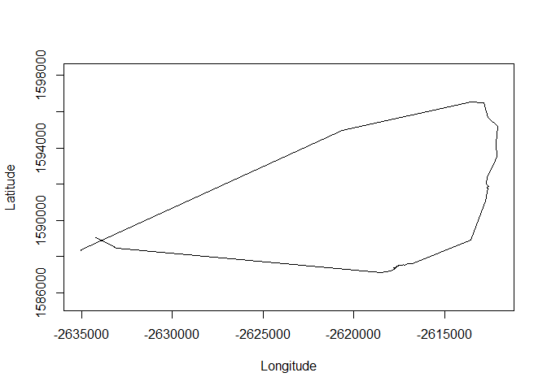

```r
move_track <- move::move(adeh_track)

plot(move_track[[26]], xlab="Longitude", ylab="Latitude", type="l", pch=16, lwd=0.5)
```

Lo siguiente es aplicar valores NA en los puntos de la trayectoria de forma regular, en este caso utilizando un tiempo de 5 minutos. Para esto creo una variable de referencia, llamada `refda` y corro la función. Por último filtro y me quedo solo con los `NA`, porque estos son los que voy a interpolar.

```r
refda <- strptime("00:00", "%H:%M", tz="GMT")
track_NA <- adehabitatLT::setNA(adeh_track, refda, 5, units = "min") # Agrego a adeh_track "NA" cada 5 min cuando falta una localizacion en ese intervalo

times_NA <- adehabitatLT::ld(track_NA) %>%
  filter(is.na(x))

head(times_NA)
```

```
##     x  y                date dx dy dist  dt R2n abs.angle rel.angle      id
## 10 NA NA 2022-12-05 16:10:00 NA NA   NA 300  NA        NA        NA ARDP003
## 11 NA NA 2022-12-05 16:15:00 NA NA   NA 300  NA        NA        NA ARDP003
## 12 NA NA 2022-12-05 16:20:00 NA NA   NA 300  NA        NA        NA ARDP003
## 13 NA NA 2022-12-05 16:25:00 NA NA   NA 254  NA        NA        NA ARDP003
## 15 NA NA 2022-12-05 16:35:00 NA NA   NA 300  NA        NA        NA ARDP003
## 16 NA NA 2022-12-05 16:40:00 NA NA   NA 300  NA        NA        NA ARDP003
##             burst pkey
## 10 ARDP003_trip_1 <NA>
## 11 ARDP003_trip_1 <NA>
## 12 ARDP003_trip_1 <NA>
## 13 ARDP003_trip_1 <NA>
## 15 ARDP003_trip_1 <NA>
## 16 ARDP003_trip_1 <NA>
```

Vamos a aplicar aplicar un algoritmo para interpolar los puntos faltantes.

```r
coastline_polar <- st_transform(coastline, crs="EPSG:3031")
track_interpolated <- data.frame() # Crea un df vacío para luego incorporarle los tracks individuales.

plot_track_list = list() # Lista vacía para incorporar las gráficas.

for(i in seq_along(move_track@idData$burst)) {

  track_sel <- move_track[[i]]

  track_name <- track_sel@idData$burst

  if (track_name %in% unique(times_NA$burst) == TRUE) {

    ts <- times_NA %>%
      filter(burst == track_name)

    t_interp <- move::interpolateTime(move_track[[i]], time=ts$date, spaceMethod='euclidean')
    t_interp_df <- as.data.frame (t_interp)
    t_record_df <- as.data.frame (move_track[[i]])

    t_interp_df <- rbind (t_interp_df, t_record_df) %>%
      arrange (timestamps)
    track_interpolated <- rbind(track_interpolated, t_interp_df)

    plot_i <- ggplot() +
      geom_sf(data=coastline_polar) +
      geom_path(data = t_record_df, aes(x, y, color = "gray")) +
      geom_point(data = t_interp_df, aes(x, y, color = "True locations"), show.legend = TRUE) +
      geom_point(data = t_record_df, aes(x, y, color = "Interpolated locations"), show.legend = TRUE) +
      scale_colour_manual(values = c("True locations" = "#EF476F", "Interpolated locations" = "#118AB2")) +
      labs(color = "") +
      coord_sf(xlim = c(st_bbox(move_track[[i]])[[1]] -1000, st_bbox(move_track[[i]])[[3]] + 1000),
               ylim = c(st_bbox(move_track[[i]])[[2]] -1000, st_bbox(move_track[[i]])[[4]] + 1000)) +
      ggtitle(paste0("By custom timestamps: ", track_name)) +
      xlab("Longitude") + ylab("Latitude") +
      theme(legend.position = c(0.85, 0.15), legend.background = element_rect(fill = "#FFFFFF00"))

    plot_track_list[[i]] <- plot_i

  } else {
    t_interp_df <- data.frame()
    t_record_df <- as.data.frame (move_track[[i]])
    t_interp_df <- rbind (t_interp_df, t_record_df) %>%
      arrange (timestamps)
    track_interpolated <- rbind(track_interpolated, t_interp_df)
  }
}
```

Visualizamos los puntos interpolados de un trip del individuo 008:

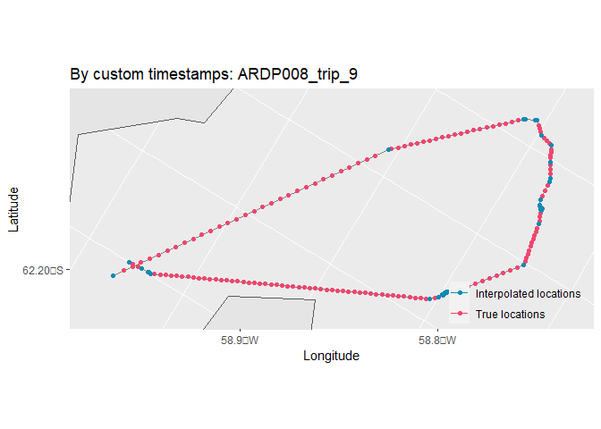

```r
plot_track_list[26]
```

# Utilization distribution and home range.

# Para la colonia

Vamos a utilizar la *“Utilization distribution”* (UD), es una probabilidad de distribución que da la densidad de probabilidad de que un animal se encuentra en un punto dado del espacio. Se estima utilizando datos sobre la ubicación de uno o varios individuos en un tiempo determinado.

El valor de h determina el efecto de suavizado aplicado a los datos. Un ancho de banda menor produce una estimación más detallada, pero es sensible a las variaciones locales en los puntos de datos. Elegir el valor del ancho de banda es muy importante, porque afecta la interpretación de la distribución de utilización.

La UD posee un parámetro llamado bandwith *h*, un valor bajo de h estima la densidad con mucha variación, mientras que un valor alto produce gran sesgo.

Vamos a buscar el valor de h utilizando un método llamado **ad hoc**, que permite ajustar el ancho de banda para nuestros datos en específico.

Primero necesitamos crear un objeto espacial que le pasaremos a la función `kernelUD` del paquete `adehabitatHR`.

```r
gps_sp <- sp::SpatialPointsDataFrame(coords = gps_df_filtered[,c("long_polar","lat_polar")],
                                  data = data.frame(gps_df_filtered),
                                  proj4string = CRS("+init=epsg:3031"))
```

Antes de calcular h por el método **ad hoc** vamos a correr la función `kernelUD`, pero con el argumento `h = "href"` con el fin de que la función calcule un valor de h de referencia.

```r
href_ud <- adehabitatHR::kernelUD(gps_sp, h = "href", grid=500, extent=0.5, kern = "bivnorm")
```

Vemos que el valor de referencia de h que nos da la función es de 2736.2882621, href.

Para buscar el valor de h *ad hoc* vamos a realizar varias itineraciones para correr la función `kernelUD` con diferentes valores de h. Estos últimos se basan en el h de referencia multiplicado por valores que lo hacen crecer y luego disminuir.

```r
hValsCorr <- seq(1.2, 0.3, by=-0.05) # Valores para multiplicar al href

h_values <- href_ud@h$h*hValsCorr # Valores de h

hValsA <- numeric(length(hValsCorr)) # Vector con el mismo numero de valores que hValsCorr
nPolygons <- numeric(length(hValsCorr)) # idem
```

Corremos el bucle:

```r
tictoc::tic()
for (j in 1:length(hValsCorr)) {
  # UD para el valor de h.
  udKerHvals <- adehabitatHR::kernelUD(gps_sp, h = h_values[j],
                                       grid=500,
                                       extent=0.5,
                                       kern = c("bivnorm"),
                                       same4all=T)
  # Almacena el valor de h.
  hValsA[j] <- as.numeric(udKerHvals@h$h)

  # Extrae el contorno del home range.
  hrKer90 <- adehabitatHR::getverticeshr(udKerHvals, percent = 90)

  # Almacena la cantidad de polígonos.
  nPolygons[j] <- length((hrKer90@polygons[[1]]@Polygons))
}
tictoc::toc()
```

```
## 27.61 sec elapsed
```

Podemos visualizar los valores obtenidos:

- Valores de h: 3283.5459146, 3146.7315015, 3009.9170884, 2873.1026753, 2736.2882621, 2599.473849, 2462.6594359, 2325.8450228, 2189.0306097, 2052.2161966, 1915.4017835, 1778.5873704, 1641.7729573, 1504.9585442, 1368.1441311, 1231.329718, 1094.5153049, 957.7008918, 820.8864786
- Número de polígonos: 2, 2, 2, 2, 2, 2, 2, 2, 2, 2, 2, 4, 4, 4, 6, 5, 10, 15, 19
- El menor número de polígonos: 2

Lo siguiente es buscar el valor de h con el menor número de polígonos, con el fin de seleccionar uno que no fraccione el polígono principal.

```r
minnPolygons <- min(nPolygons) # Menor numero de polígonos
h_adhoc <- hValsA[max(which(nPolygons==minnPolygons))]
h_adhoc
```

```
## [1] 1915.402
```

# Para los individuos

Ahora vamos a calcular el área de utilización, pero para cada individuo utilizando el h **ad hoc** obtenido. Primero creamos un objeto de puntos espaciales.

```r
gps_ind_sp <- SpatialPointsDataFrame(coords = gps_df_filtered[,c("long_polar","lat_polar")],
                                  data = data.frame(IND = gps_df_filtered[,"gps_id"]),
                                  proj4string = CRS("+init=epsg:3031"))
```

Utilizando la función `kernelUD` obtenemos la distribución de utilización.

```r
allUD_ind <- kernelUD(gps_ind_sp,
                      h = h_adhoc,
                      grid=500,
                      extent=1,
                      kern = "bivnorm")

# Calcula el área de kernel entre 5 y 95 de densidad, para cada individuo.
area_HR_hadhoc <- allUD_ind %>%
  kernel.area(percent = c(5, seq(10,90,by=10), 95), unin = "m", unout = "km2") %>%
  data.frame()

# to reshape into long format
area_HR_hadhoc_transp <- reshape(area_HR_hadhoc, varying = list(names(area_HR_hadhoc)),
                                 times = names(area_HR_hadhoc),
                                 ids = rownames(area_HR_hadhoc),
                                 direction = "long")

# Nombra las columnas
names(area_HR_hadhoc_transp)[3] <- "isopleth"
names(area_HR_hadhoc_transp)[1] <- "IND"
names(area_HR_hadhoc_transp)[2] <- "area"
# Convierte valores
area_HR_hadhoc_transp$isopleth <- as.numeric(area_HR_hadhoc_transp$isopleth)
area_HR_hadhoc_transp$IND <- as.factor(area_HR_hadhoc_transp$IND)
rownames(area_HR_hadhoc_transp) <- NULL
# Visualizamos
paged_table(area_HR_hadhoc_transp)
```

| IND | area | isopleth |
| --- | --- | --- |
| ARDP003 | 4.145972 | 5 |
| ARDP003 | 8.991264 | 10 |
| ARDP003 | 20.280295 | 20 |
| ARDP003 | 33.367579 | 30 |
| ARDP003 | 49.501902 | 40 |
| ARDP003 | 69.382585 | 50 |
| ARDP003 | 94.258415 | 60 |
| ARDP003 | 125.977595 | 70 |
| ARDP003 | 170.184642 | 80 |
| ARDP003 | 245.011937 | 90 |

[output cut: 111 more lines]

# Identificando áreas de importancia

El primer paso es especificar dónde se encuentra la colonia y almacenarlo en un data frame.

```r
colony <- data.frame(Latitude = -62.2167,
                     Longitude = -58.9333) %>%
  st_as_sf(coords = c("Longitude", "Latitude"),
           crs = 4326) %>%
  st_transform(crs = 3031) %>%
  st_coordinates() %>%
  as.data.frame() %>%
  rename(Latitude = X,
         Longitude = Y)
```

Track2KBA necesita que la información suministrada esté en un formato específico. Para esto, existe una función del mismo paquete llamada `formatFields`, la cual utilizaremos para cargar los datos.

```r
dataGroup <- formatFields(
  dataGroup = track_interpolated,
  fieldID   = "id",
  fieldDateTime = "timestamps",
  fieldDate = NULL,
  fieldTime = NULL,
  fieldLon  = "x",
  fieldLat  = "y"
)

tracks <- SpatialPointsDataFrame(coords = dataGroup[,c("Longitude","Latitude")],
                                 data = dataGroup,
                                 proj4string = CRS("+init=epsg:3031"))
```

Calculamos UD para cada individuo, esta vez con la función `estSpaceUse`. Un argumento interesante es el de `levelUD`, aquí podemos especificar un cuantil de distribución, es decir donde el animal pasa el x% de su tiempo.

```r
KDE <- estSpaceUse(
  tracks = tracks,
  scale = h_adhoc/1000, # Debe estar en kilometros, no en metros.
  levelUD = 90,
  res = NULL,
  polyOut = TRUE
)
```

Visualizamos:

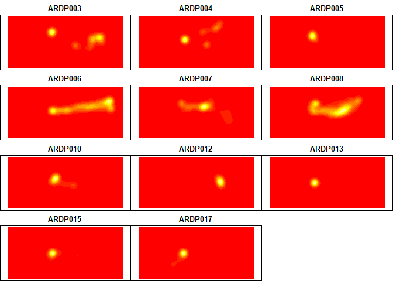

```
## $mfrow
## [1] 4 3
```

```r
mapKDE(KDE = KDE$KDE.Surface, colony = colony) # Raster para cada individuo
```

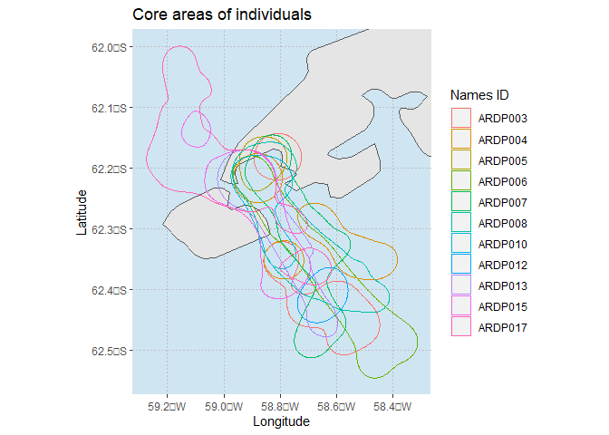

```r
world <- ne_countries(scale = 10, returnclass = "sf") %>%
  st_transform(4326) %>%
  st_make_valid()

ggplot() +
  geom_sf(data=world) +
  geom_sf(data=KDE$UDPolygons, aes(color=id), alpha = 0) +
  coord_sf(xlim = c(st_bbox(KDE$UDPolygons)[[1]], st_bbox(KDE$UDPolygons)[[3]]),
           ylim = c(st_bbox(KDE$UDPolygons)[[2]], st_bbox(KDE$UDPolygons)[[4]])) +
  ggtitle("Core areas of individuals") +
      xlab("Longitude") + ylab("Latitude") + guides(color=guide_legend(title="Names ID")) +
  theme(panel.background = element_rect(fill = "#D0E5F2"),
        panel.grid.major = element_line(linetype = "dotted", colour = "gray", size = 0.25))
```

También podemos visualizar los estadísticos sobre el área de kernel de los individuos.

```r
summary(KDE$UDPolygons$area)
```

```
##    Min. 1st Qu.  Median    Mean 3rd Qu.    Max.
##   71.31  197.04  263.49  262.50  350.75  454.39
```

## Representatividad

Estimamos la representatividad del grupo muestreado.

```r
repr <- repAssess(
  tracks    = tracks,
  KDE       = KDE$KDE.Surface,
  levelUD   = 90,
  iteration = 20,
  bootTable = FALSE)
```

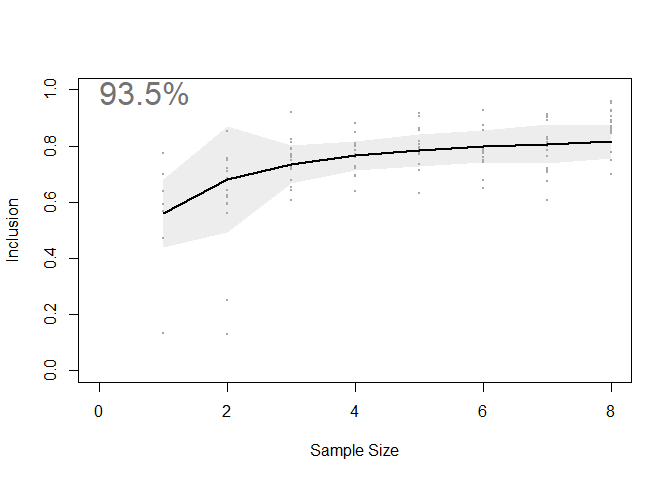

## Áreas utilizadas regularmente

Para identificar áreas utilizadas regularmente, por una parte significativa de la población, vamos a utilizar la función `findSite`.

```r
Site_core <- findSite(
  KDE = KDE$KDE.Surface,
  represent = repr$out,
  levelUD = 90,
  # thresh = 10, #% min de la poblacion que usa la celda para considerar area de importancia
  #samples that are >90%, 80-89%, 70-79%, and <70% representative set the threshold
  #at 10%, 12.5%, 25%, and 50% of the population, respectively
  popSize = NULL,
  polyOut = FALSE
)
```

Visualizamos:

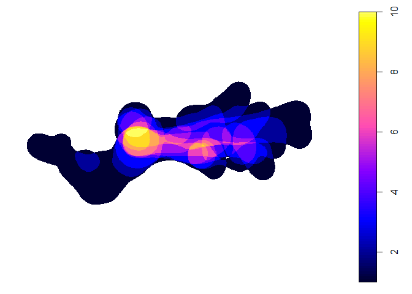

```r
Sitemap <- mapSite(Site_core, colony = colony, show = FALSE)
```

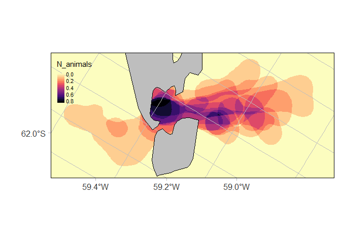

```r
map_paises <- tm_shape(world, bbox = st_bbox(tracks))+
  tm_borders(lwd=0.3, col = "black")+
  tm_fill("grey")

tmap_mode("plot")
tmap_options(check.and.fix = TRUE)

map_pen <-
  tm_shape(Site_core) +
  tm_raster("N_animals", style="cont", palette = "-magma", colorNA=NULL, colorNULL=NULL) +
  tm_graticules(col = "grey", lwd = 0.2, labels.size = 1)+
  tm_layout(bg.color = "lightblue") +
  map_paises

map_pen
```

# Comentario final

En resumen, se logró identificar un home range de alimentación para los pingüinos Papua en la Isla Ardley. Además, se describió los home range de cada individuo, lo que es útil para conocer sus patrones de movimiento y comportamiento en relación con la búsqueda del alimento.